# Assignment 4

Data Science for Biomedical Informatics (BMIN503/EPID600)

###Instructions - Download the Rmd version of this file - Complete the questions below in RStudio using the Rmd file as a template - Replace text in brackets with your answers. (There is no need to keep the brackets). - Save the Rmd document as Assignment4_*YOUR LAST NAME*.Rmd - Create an HTML version using knitr - Turn in completed Assignment4_*YOUR LAST NAME*.html file in Canvas under Assignments -> Assignment 4 - Your assignment **must** be in html format or it will not be graded - Grades will be assigned according to point scheme below and computed as a percentage of total possible points - Lateness policy: If an urgent and unforseen circumstance comes up and you need an extension to turn in an assignment, please contact Blanca and/or Sherrie as soon as possible. Unless there is an arrangement in place, late assignments will be scored as follows: - 25% of total score if 1 day late - 50% of total score if 2 days late - 75% of total score if 3 days late - Assignment will not be graded if 4 or more days late - DUE DATE: 10/23/18

###Final Project - Meeting Progress 1. What have you learned from the faculty/staff (name, title, division/department) you have already met with to discuss your project? *(3 points)*

I met with Dr. Roland Dunbrack and he told me that amyloid protein prediction was a field of interest and possibly achiveable with my data. He also educated me on the nature and function of disordered regions within protein, something I hope to implement into my model as a feature of the data.

Meeting with Dr. Moore made me think about neural nets. One of his post-docs was an expert on them, and I’m considering using one as a model in the final project.

I haven’t been able to get a meeting with Dr. Graciela-Gonzalez but I’m working on it!

###Visualization, Machine Learning and Model Evaluation 2. There is a simulated dataset [here](https://raw.githubusercontent.com/HimesGroup/BMIN503/master/DataFiles/assignment4_data.txt) of 100 measures taken for 1000 subjects. Read in the data file, and using some of the R functions discussed in class (show your code below!), answer the following questions by inserting code below each bullet to provide the answer directly. *(9 points)*

```r
library(dplyr)
```

```r
library(ggplot2)
library(randomForest)
data <- read.table(url("https://raw.githubusercontent.com/HimesGroup/BMIN503/master/DataFiles/assignment4_data.txt"), header = TRUE)
```

```
+ How many cases/controls are in the dataset?
```

```r
table(data$status)
```

```
##
##    Case Control
##     498     502
```

[output not shown]

```r
data.case <- filter(data, status=='Case')
data.control <- filter(data, status=='Control')

col_p <- list()
for (i in c(2:ncol(data))) {
  #print(i)
  t_res = t.test(data.case[, i], data.control[, i])
  p_val = t_res["p.value"][[1]]
  if (p_val <= 0.05) {
    col_p[colnames(data)[i]] <- p_val
  }
}
col_p.sorted <- col_p[order(unlist(col_p))]
col_p.sorted
```

```
## $v1
## [1] 7.627956e-54
##
## $v100
## [1] 2.724283e-40
##
## $v23
## [1] 5.206139e-38
##
## $v50
## [1] 1.127907e-15
##
## $v65
## [1] 0.004296632
##
## $v67
## [1] 0.004463176
##
## $v44
## [1] 0.01418707
##
## $v62
## [1] 0.0307009
##
## $v22
## [1] 0.03155932
##
## $v80
## [1] 0.03389481
##
## $v79
## [1] 0.04840781
```

Based on the significance, it appears that V1, V100, V23, V50, V65, and V67 are quite distant from the significance cutoff of 0.05. Based on that statistical inference, these variables would be good targets for more understanding. The others might require more work to make more useful for prediction of Case/Control.

```
+ Create a plot to visualize how the values of the individual variable with lowest p-value differ between cases and controls.
```

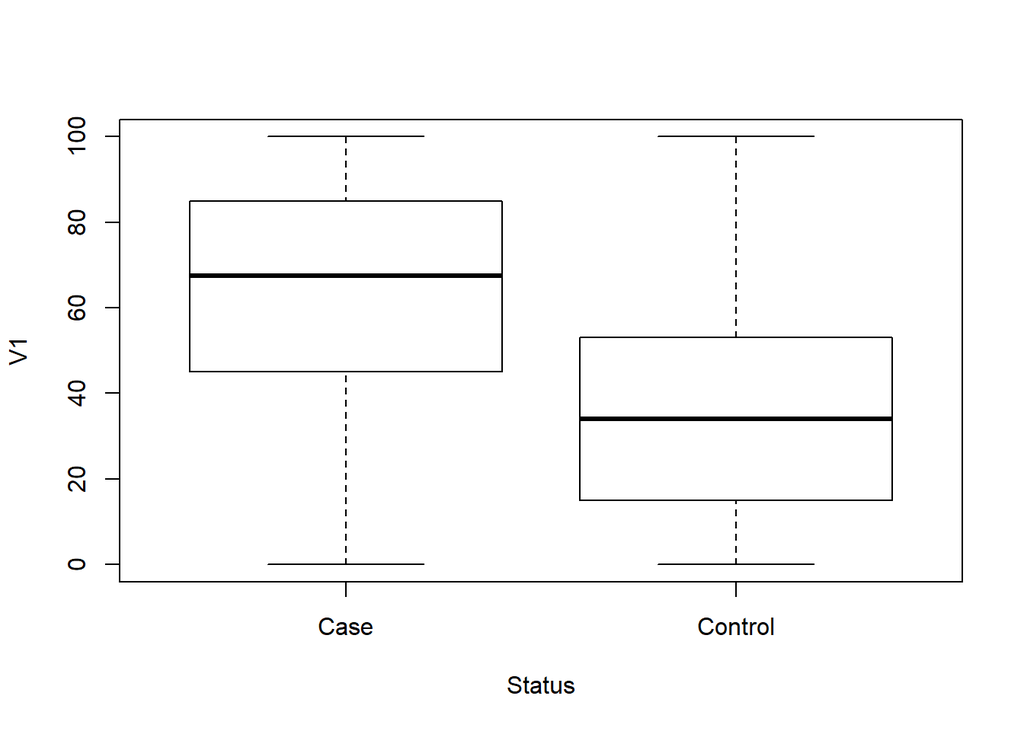

```r
lowest_p <- names(col_p.sorted[[1]])
boxplot(v1~status, data=data, xlab="Status", ylab="V1")
```

3. We will use hierarchical clustering with the independent variables (i.e. leave the *status* variable out) to find out whether we can arrive at the *status* label from the independent variables. Since we know there should be 2 categories, use this information in your analysis. Insert code below each bullet to provide answers. *(9 points)*
   - Create a dendrogram using `hclust` and use the original *status* variable to color the leaves.

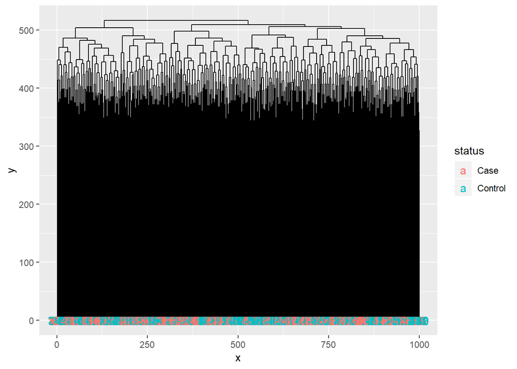

```r
#install.packages("ggdendro")

library(ggdendro)
data.hclust <- hclust(dist(data[,1:ncol(data)]), method="complete")
data.dend <- dendro_data(as.dendrogram(data.hclust))
labels <- label(data.dend)
labels$status <- data$status[as.numeric(levels(labels$label))]
ggplot(segment(data.dend)) +
    geom_segment(aes(x=x, y=y, xend=xend, yend=yend)) +
    geom_text(data=labels, aes(label=label, x=x, y=0, color=status), size=4)
```

```r
data.hclust.s <- hclust(dist(data[,1:ncol(data)]), method="single")
```

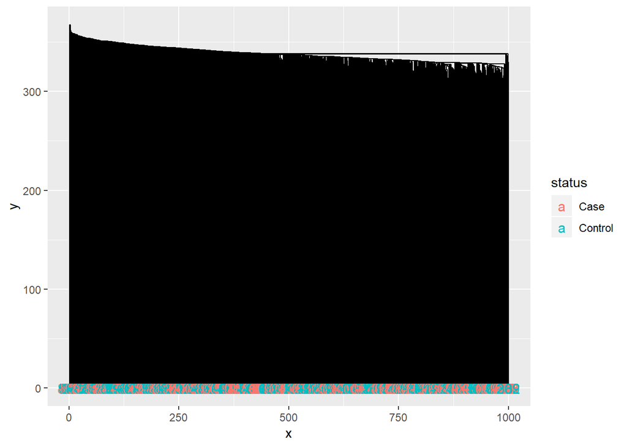

```r
data.dend.s <- dendro_data(as.dendrogram(data.hclust.s))
labels <- label(data.dend.s)
labels$status <- data$status[as.numeric(levels(labels$label))]
ggplot(segment(data.dend.s)) +
    geom_segment(aes(x=x, y=y, xend=xend, yend=yend)) +
    geom_text(data=labels, aes(label=label, x=x, y=0, color=status), size=4)
```

```r
data.hclust.a <- hclust(dist(data[,1:ncol(data)]), method="average")
```

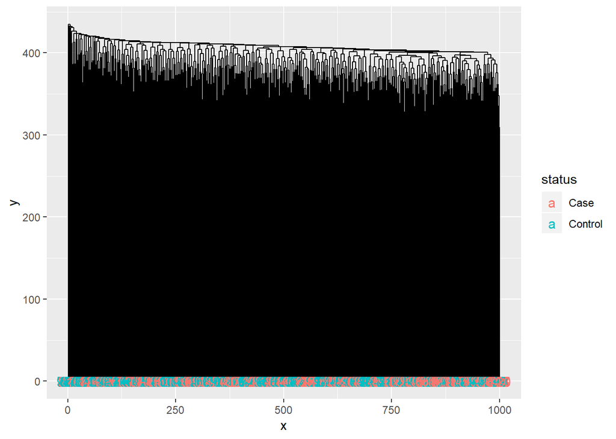

```
+ Use a table to show how many cases/controls are properly classified.
```

```r
data.dend.a <- dendro_data(as.dendrogram(data.hclust.a))
labels <- label(data.dend.a)
labels$status <- data$status[as.numeric(levels(labels$label))]
ggplot(segment(data.dend.a)) +
    geom_segment(aes(x=x, y=y, xend=xend, yend=yend)) +
    geom_text(data=labels, aes(label=label, x=x, y=0, color=status), size=4)
```

```r
data.hclust.cut <- cutree(data.hclust, 2) #Cut where there are 3 clusters
table(data$status, data.hclust.cut)
```

```
##          data.hclust.cut
##             1   2
##   Case    154 344
##   Control 155 347
```

```r
data.hclust.cut.s <- cutree(data.hclust.s, 2) #Cut where there are 3 clusters
table(data$status, data.hclust.cut.s)
```

```
##          data.hclust.cut.s
##             1   2
##   Case    497   1
##   Control 502   0
```

```r
data.hclust.cut.a <- cutree(data.hclust.a, 2) #Cut where there are 3 clusters
table(data$status, data.hclust.cut.a)
```

```
##          data.hclust.cut.a
##             1   2
##   Case    498   0
##   Control 501   1
```

```
+ In 1-2 sentences describe the relationship between the independent variables and _status_ based on your results.
```

By including all of the independent variables in classifying the status of each record - the clustering algorithm that tries to build “similar clusters” struggles to call observations accurately. It seems to have just as many true positives and false negatives and just as many true negatives and false positives. Utilizing other methods, the classifier breaks down in its ability to call true negatives. It instead calls virtually everything a case.

4. Compare the predictive accuracy of 1) Logistic regression and 2) Random forest multivariate models of *status* as outcome and using all independent variables simultaneously. Hint: you can modify the random forest and cross validation code from the practicum files used in class. Insert code below each bullet to provide answers. *(12 points)*
   - Create a logistic regression model. How many variables are significant at p<0.05? Store the predicted values of the training data into a variable called glm.pred.

```r
train_data_ind <- sample(seq_len(nrow(data)), size=floor(0.75*nrow(data)))

train_data <- data[train_data_ind,]
test_data <- data[-train_data_ind,]

glm_all <- glm(status~., family=binomial(link='logit'), data=train_data)
coef_less_sig <- summary(glm_all)$coeff[,4] <= 0.05
#coef_less_sig
# Num significant variables
print("Num coefficients that are significant: ")
```

```
## [1] "Num coefficients that are significant: "
```

```r
length(coef_less_sig[coef_less_sig==TRUE])
```

```
## [1] 0
```

```r
# Train data predictions - they're perfect!
glm.pred <- predict(glm_all, data, type="response")
```

```
+ Create a random forest model. What are the most important predictors according to gini importance scores (i.e. MeanDecreaseGini)? Store the predicted values of the training data into a variable called rf.pred.
```

```r
data.rf <- randomForest(status ~ ., data=train_data, ntree=100, importance=TRUE)
sorted_preds <- sort(data.rf$importance[,4], decreasing=TRUE)
print("Top 5 predictors by MeanDecreaseGini")
```

```
## [1] "Top 5 predictors by MeanDecreaseGini"
```

```r
print(names(sorted_preds[1:5]))
```

```
## [1] "v1"   "v23"  "v100" "v50"  "v44"
```

```r
rf.pred <- as.numeric(factor(predict(data.rf, data, type="response")))
```

[output not shown]

```r
library(boot)
data.cv.glm <- cv.glm(train_data, glm_all, K=10)
data.cv.rf <- cv.glm(train_data, data.rf, K=10)
```

[output not shown]

```r
N = nrow(data)
K = 10
set.seed(1234)
s = sample(1:K, size=N, replace=T)
glm.pred.outputs <- vector(mode="numeric", length=N)
obs.outputs <- vector(mode="numeric", length=N)
rf.pred.outputs <- vector(mode="numeric", length=N)
offset <- 0
for(i in 1:K){
    train <- filter(data, s != i)
    test <- filter(data, s == i)
    obs.outputs[1:length(s[s==i]) + offset] <- test$status

    #GLM train/test
    glm <- glm(status~., data=train, family=binomial(logit))
    glm.pred.curr <- predict(glm, test, type="response")
    glm.pred.outputs[1:length(s[s==i]) + offset] <- glm.pred.curr
  #RF train/test
    rf <- randomForest(status ~ ., data=train, ntree=100, importance=TRUE)
    rf.pred.curr <- predict(rf, test, type="response")
    rf.pred.outputs[1:length(s[s==i]) + offset] <- rf.pred.curr

    offset <- offset + length(s[s==i])
}
library(pROC)
#GLM RocAuc
roc(data$status, glm.pred, ci=TRUE)
```

```
##
## Call:
## roc.default(response = data$status, predictor = glm.pred, ci = TRUE)
##
## Data: glm.pred in 498 controls (data$status Case) < 502 cases (data$status Control).
## Area under the curve: 0.9834
## 95% CI: 0.9751-0.9916 (DeLong)
```

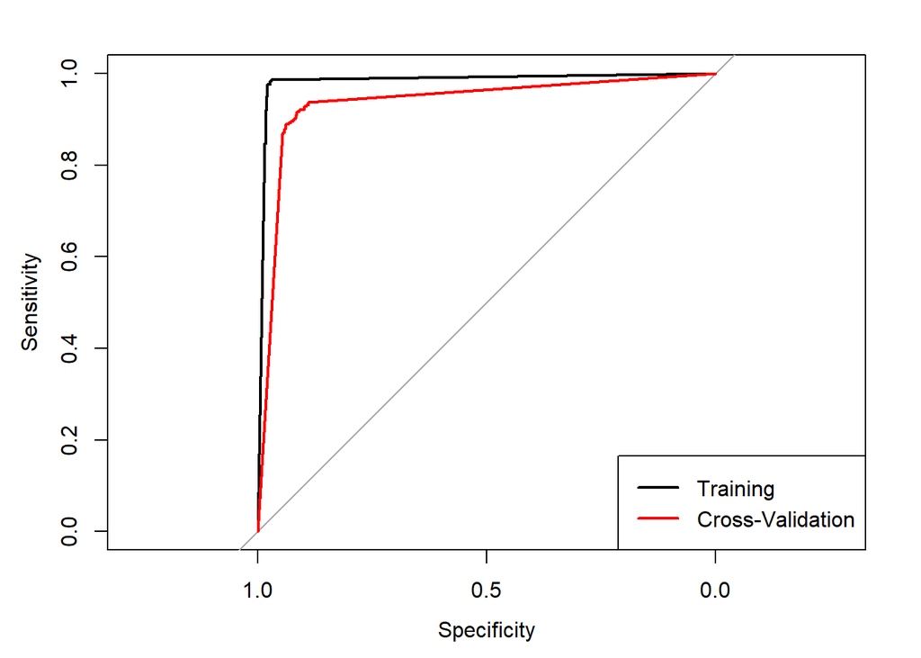

```r
# Plot roc curve of
plot.roc(data$status, glm.pred, ci=TRUE)
plot.roc(obs.outputs, glm.pred.outputs, col="red", add=TRUE)
legend("bottomright", legend=c("Training", "Cross-Validation"), col=c("black", "red"), lwd=2)
```

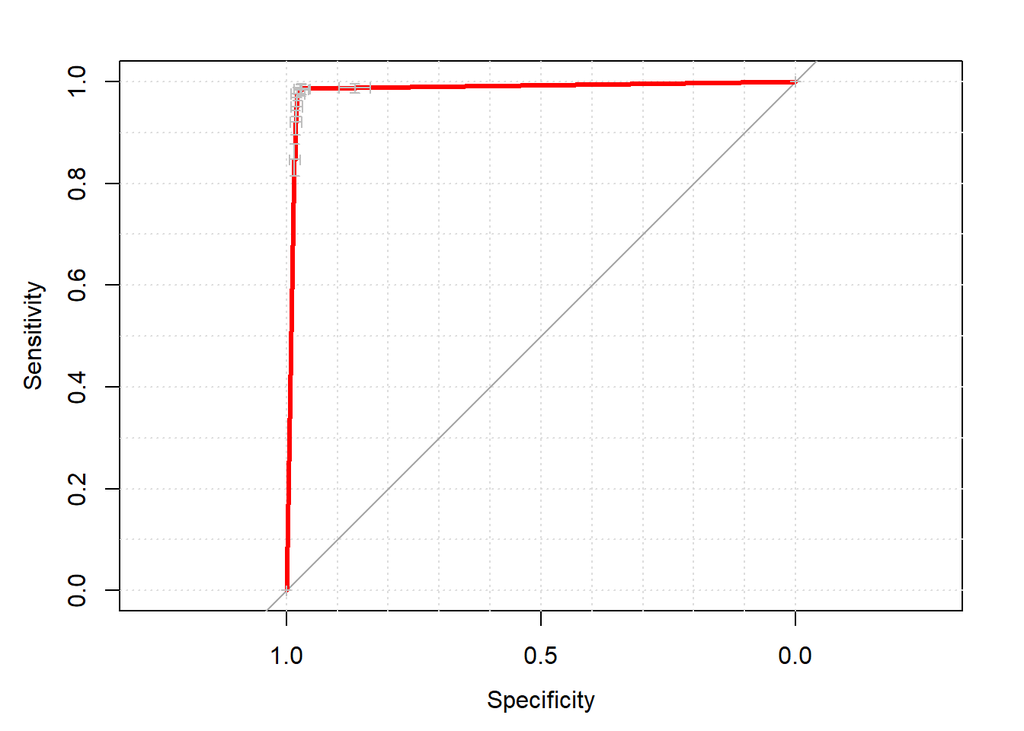

```r
glm.roc <- plot.roc(data$status, glm.pred, col="red", lwd=3, grid=TRUE)
plot(ci.thresholds(glm.roc), col="grey")
```

```r
#RF RocAuc
roc(data$status, rf.pred, ci=TRUE)
```

```
##
## Call:
## roc.default(response = data$status, predictor = rf.pred, ci = TRUE)
##
## Data: rf.pred in 498 controls (data$status Case) < 502 cases (data$status Control).
## Area under the curve: 0.958
## 95% CI: 0.9456-0.9705 (DeLong)
```

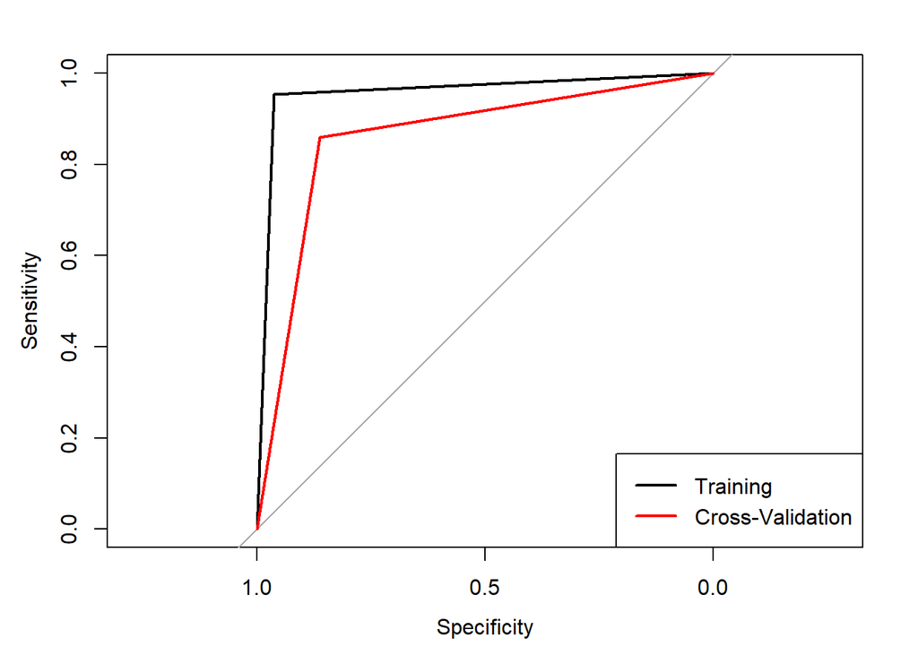

```r
# Plot roc curve of
plot.roc(data$status, rf.pred, ci=TRUE)
plot.roc(obs.outputs, rf.pred.outputs, col="red", add=TRUE)
legend("bottomright", legend=c("Training", "Cross-Validation"), col=c("black", "red"), lwd=2)
```

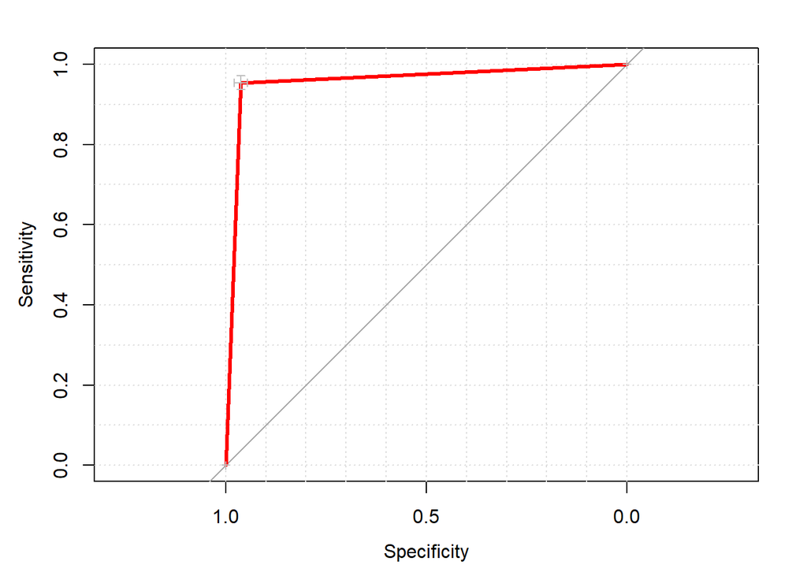

```
+ How do the AUCs for the random forest compare to the internal out-of-bag error rate estimate reported by the randomForest function? Explain how the two measures were obtained.
```

```r
rf.roc <- plot.roc(data$status, rf.pred, col="red", lwd=3, grid=TRUE)
plot(ci.thresholds(rf.roc), col="grey")
```

5. Rather than using all variables, create logistic regression and random forest predictive models using the “best” variables according to each method (i.e. the top-ranked variables according to standard metrics for each test). Insert code below each bullet to provide answers. *(9 points)*
   - Compare the top-ranked variables according to (1) univariate p-values <0.05 from logistic regression tests provided in question 2 and (2) by gini score for random forest from question 4. Are the top variables consistent?

```r
len_top_p <- length(col_p.sorted)
names(col_p.sorted)
```

```
##  [1] "v1"   "v100" "v23"  "v50"  "v65"  "v67"  "v44"  "v62"  "v22"  "v80"  "v79"
```

```r
names(sorted_preds)[1:len_top_p]
```

```
##  [1] "v1"   "v23"  "v100" "v50"  "v44"  "v93"  "v41"  "v67"  "v46"  "v81"  "v33"
```

```
+ Create logistic regression and random forest models using the top variables. For each model, check the predictive accuracy using the training data as well as via 10-fold cross-validation. Report the corresponding AUC and create ROC plots as you did in question 4. How does the predictive accuracy of the models compare to those using the entire dataset obtained in question 4? Explain any differences in a few sentences.
```

```r
# We'll go with the top 11 variables
# Log reg
top_logreg_cols <- append(names(col_p.sorted),"status")
top_glm <- glm(status~., data=data[,top_logreg_cols], family=binomial(logit))
top_glm_preds <- predict(top_glm, data[, top_logreg_cols], type="response")

#append(top_logreg, "status")
top_rf_cols <- append(names(sorted_preds[1:len_top_p]),"status")
top_rf <- randomForest(status~., data=data[,top_rf_cols], ntree=100, importance=TRUE)
top_rf_preds <- as.numeric(factor(predict(top_rf, data[,top_rf_cols], type="response")))
#append(top_rf, "status")
N = nrow(data)
K = 10
set.seed(1234)
s = sample(1:K, size=N, replace=T)
glm_top.pred.outputs <- vector(mode="numeric", length=N)
rf_top.pred.outputs <- vector(mode="numeric", length=N)
top_obs.outputs <- vector(mode="numeric", length=N)
offset <- 0
for(i in 1:K){
    train <- filter(data, s != i)
    test <- filter(data, s == i)
    top_obs.outputs[1:length(s[s==i]) + offset] <- test$status

    #GLM train/test
    glm <- glm(status~., data=train[,top_logreg_cols], family=binomial(logit))
    glm.pred.curr <- predict(glm, test[,top_logreg_cols], type="response")
    glm_top.pred.outputs[1:length(s[s==i]) + offset] <- glm.pred.curr
  #RF train/test
    rf <- randomForest(status ~ ., data=train[,top_rf_cols], ntree=100, importance=TRUE)
    rf.pred.curr <- predict(rf, test[,top_rf_cols], type="response")
    rf_top.pred.outputs[1:length(s[s==i]) + offset] <- rf.pred.curr

    offset <- offset + length(s[s==i])
}
#GLM RocAuc
roc(data$status, top_glm_preds, ci=TRUE)
```

```
##
## Call:
## roc.default(response = data$status, predictor = top_glm_preds,     ci = TRUE)
##
## Data: top_glm_preds in 498 controls (data$status Case) < 502 cases (data$status Control).
## Area under the curve: 0.9917
## 95% CI: 0.9881-0.9952 (DeLong)
```

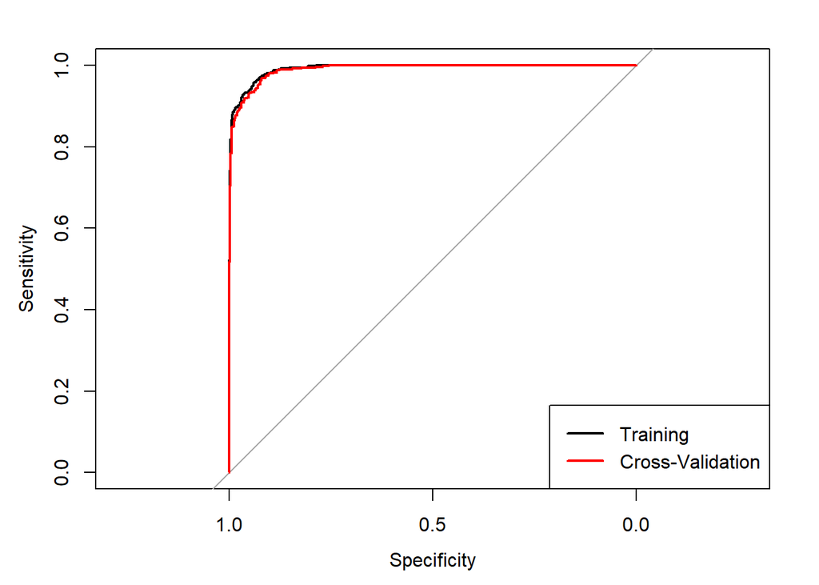

```r
# Plot roc curve of
plot.roc(data$status, top_glm_preds, ci=TRUE)
plot.roc(top_obs.outputs, glm_top.pred.outputs, col="red", add=TRUE)
legend("bottomright", legend=c("Training", "Cross-Validation"), col=c("black", "red"), lwd=2)
```

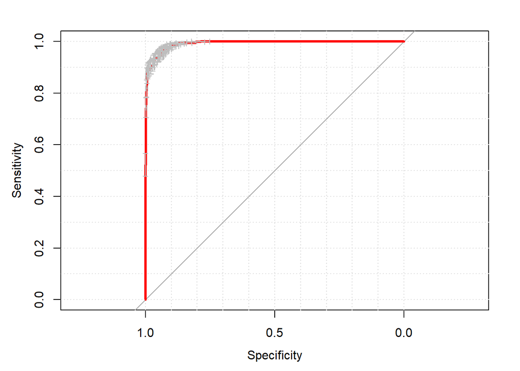

```r
glm_top.roc <- plot.roc(data$status, top_glm_preds, col="red", lwd=3, grid=TRUE)
plot(ci.thresholds(glm_top.roc), col="grey")
```

```r
#RF RocAuc
roc(data$status, top_rf_preds, ci=TRUE)
```

```
##
## Call:
## roc.default(response = data$status, predictor = top_rf_preds,     ci = TRUE)
##
## Data: top_rf_preds in 498 controls (data$status Case) < 502 cases (data$status Control).
## Area under the curve: 1
## 95% CI: 1-1 (DeLong)
```

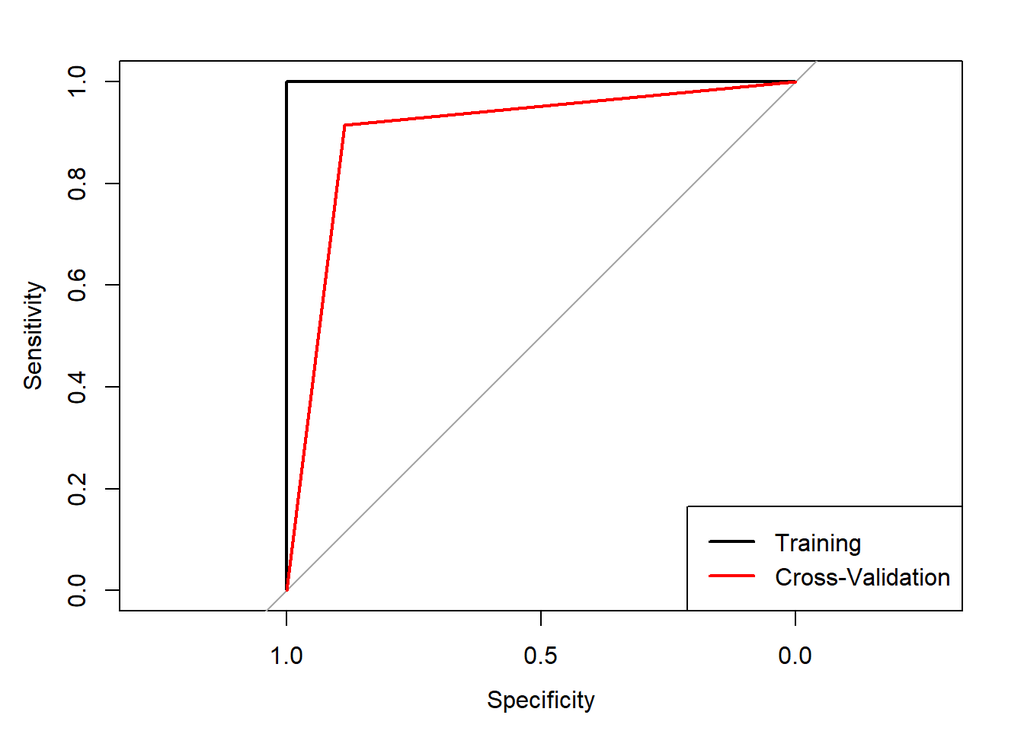

```r
# Plot roc curve of
plot.roc(data$status, top_rf_preds, ci=TRUE)
plot.roc(top_obs.outputs, rf_top.pred.outputs, col="red", add=TRUE)
legend("bottomright", legend=c("Training", "Cross-Validation"), col=c("black", "red"), lwd=2)
```

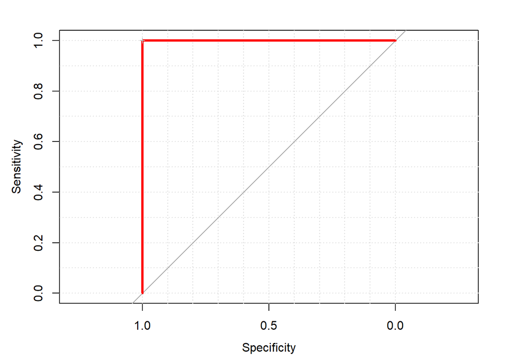

```
+ What models would be preferable in most situations, those you created in question 4 or 5?
```

```r
rf_top.roc <- plot.roc(data$status, top_rf_preds, col="red", lwd=3, grid=TRUE)
plot(ci.thresholds(rf_top.roc), col="grey")
```

There’s always a trade-off between performance and generalizability. If I were building a model that is meant to be deployed on data the model hasn’t seen, I would opt for the simplified models in 5. These models are more likely to be useful and accurate on data the model wasn’t trained on. These models haven’t learned all of the idiosyncrasies of the training data it was given. Had it learned those quirks of that specific sample of data, it would predict future data based on those characteristics which the future data might not have - decreasing performance.

The other benefit of the models in 5 is that they are more easily described to other stake-holders of the project. Being able to explain what you did and why it might work typically has value, so I would prefer to maintain that ability.